# Exercise 8 – CART

[Introduction to Machine Learning](https://slds-lmu.github.io/i2ml/)

Show All Solutions

Only R | Only Python | Print

**Hint: Useful libraries**

**R**

```python
library(mlr3verse)
library(rattle)
```

**Python**

```python
import numpy as np
import pandas as pd
import matplotlib.pyplot as plt
from sklearn.tree import DecisionTreeRegressor, plot_tree
```

## Exercise 1: Splitting criteria

**NoteLearning goals**

1. Perform split computation with pen and paper
2. Understand why additional splits never increase the training risk

Consider the following dataset:

| $i$ | $x^{(i)}$ | $y^{(i)}$ |
| --- | --- | --- |
| 1 | 1.0 | 1.0 |
| 2 | 2.0 | 1.0 |
| 3 | 7.0 | 0.5 |
| 4 | 10.0 | 10.0 |
| 5 | 20.0 | 11.0 |

1. Compute the first split point the CART algorithm would find for the given data set (with pen and paper or in `R`, resp. `Python`). Use mean squared error (MSE) to assess the empirical risk.

**Solution**

**Pen-and-paper solution**

**TipProcedure**

1. We have only one split variable $x$. We probe all binary splits, where thresholds are placed equidistant between the observed feature values (think about why this might help generalization).
2. For each threshold:
- Map observations to child nodes resulting from split at that threshold
- Compute optimal constant prediction and resulting loss in both child nodes
- Aggregate to obtain overall loss of split
3. Choose optimal split w.r.t. empirical risk reduction.

**WarningAccounting for node size**

Two scenarios in aggregating the risk contributions from both candidate child nodes:

- Child node risk is sum of pointwise losses without accounting for number of observations $\rightsquigarrow$ *simple* average
- Child node risk is average of pointwise losses, thus accounting for number of observations $\rightsquigarrow$ *weighted* average

**Split points**

Split candidates $t \in \{1.5, 4.5, 8.5, 15\}$, leading to the following child nodes:

$$\begin{align*}
\mathcal{N}_1(t) &= \{ (x,y) \in \mathcal{N}: x \leq t \}, ~~
\mathcal{N}_2(t) = \{ (x,y) \in \mathcal{N}: x > t \}.
\end{align*}$$

**Risk per split point**

Calculate $\mathcal{R}(\mathcal{N}, t)$ for each split point:

- $x \leq 1.5$
  - Predictions: $c_1 = \tfrac{1}{1} \sum_{i = 1}^1 y_i = 1, ~~ c_2 = \tfrac{1}{4} \sum_{i = 2}^5 y_i = 5.625$
  - Risk left: $\rho_{\text{MSE}}(\mathcal{N}_1, 1.5) = 0$
  - Risk right: $\rho_{\text{MSE}}(\mathcal{N}_2, 1.5) = \tfrac{1}{4}((1 - 5.625)^2 + (0.5 - 5.625)^2 + (10 - 5.625)^2 + (11 - 5.625)^2)$
  - Aggregate risk: $\mathcal{R}(\mathcal{N}, 1.5) = \tfrac{|\mathcal{N}_1|}{|\mathcal{N}|} \rho_{\text{MSE}}(\mathcal{N}_1, 1.5) +\tfrac{|\mathcal{N}_2|}{|\mathcal{N}|} \rho_{\text{MSE}}(\mathcal{N}_2, 1.5) = \tfrac{1}{5} \cdot 0 + \tfrac{4}{5} \cdot 23.925 = 19.14$
- $x \leq 4.5$ $\rightsquigarrow$ $\mathcal{R}(\mathcal{N}, 4.5) = 13.43$
- $x \leq 8.5$ $\rightsquigarrow$ $\mathcal{R}(\mathcal{N}, 8.5) = 0.13$ $\rightsquigarrow$ **optimal**
- $x \leq 15$ $\rightsquigarrow$ $\mathcal{R}(\mathcal{N}, 15) = 12.64$

**R**

Write function to perform MSE-based splits:

```r
x <- c(1, 2, 7, 10, 20)
y <- c(1, 1, 0.5, 10, 11)

compute_mse <- function(y) mean((y - mean(y))**2)

compute_total_mse <- function(yleft, yright) {
  num_left <- length(yleft)
  num_right <- length(yright)
  w_mse_left <- num_left / (num_left + num_right) * compute_mse(yleft)
  w_mse_right <- num_right / (num_left + num_right) * compute_mse(yright)
  w_mse_left + w_mse_right
}

perform_split <- function(x, y) {
  # try out all unique points as potential split points and ...
  unique_sorted_x <- sort(unique(x))
  split_points <- head(unique_sorted_x, length(unique_sorted_x) - 1) +
    0.5 * diff(unique_sorted_x)

  node_mses <- lapply(
    split_points,
    function(i) {
      y_left <- y[x <= i]
      y_right <- y[x > i]
      # ... compute SS in both groups
      mse_split <- compute_total_mse(y_left, y_right)
      print(sprintf("split at %.2f: empirical risk = %.2f", i, mse_split))
      mse_split
    }
  )

  # select the split point yielding the maximum impurity reduction
  split_points[which.min(node_mses)]
}
```

Apply to dataset:

```r
perform_split(x, y) # 3rd obs is best split point
```

```
[1] "split at 1.50: empirical risk = 19.14"
[1] "split at 4.50: empirical risk = 13.43"
[1] "split at 8.50: empirical risk = 0.13"
[1] "split at 15.00: empirical risk = 12.64"
```

8.5

**Python**

Imports

```python
import numpy as np
import pandas as pd
import matplotlib.pyplot as plt
from sklearn.tree import DecisionTreeRegressor, plot_tree
```

Write function to perform MSE-based splits:

```python
def find_best_split(x_train, y_train):
    best_threshold = None
    min_risk = np.inf
    unique_sorted_x = np.unique(x_train)
    unique_sorted_x.sort()
    thresholds = (unique_sorted_x[1:] + unique_sorted_x[:-1]) / 2
    mse = lambda y: np.mean((y - y.mean()) ** 2)

    for t in thresholds:
        y_left, y_right = y_train[x_train <= t], y_train[x_train > t]
        weight_left = len(y_left) / len(y_train)
        t_mse = weight_left * mse(y_left) + (1 - weight_left) * mse(y_right)
        print("split at %.2f: empirical risk = %.2f" % (t, t_mse))
        if t_mse < min_risk:  # save best split
            min_risk = t_mse
            best_threshold = t

    print("best split at ", best_threshold)
    return {"threshold": best_threshold, "empirical_risk": min_risk}
```

Apply to dataset:

```python
x = np.array([1, 2, 7, 10, 20])
y = np.array([1, 1, 0.5, 10, 11])
find_best_split(x, y)
```

```
split at 1.50: empirical risk = 19.14
split at 4.50: empirical risk = 13.43
split at 8.50: empirical risk = 0.13
split at 15.00: empirical risk = 12.64
best split at  8.5
```

```
{'threshold': 8.5, 'empirical_risk': 0.13333333333333333}
```

2. Explain why performing further splits can never result in a higher overall risk with $L2$ loss as a splitting criterion.

**Solution**

The variance of a subset of the observations in a node cannot be higher than the variance of the entire node, so it’s not possible to make the tree worse (w.r.t. training error) by introducing a further split.

## Exercise 2: CART hyperparameters

**NoteLearning goals**

Understand the effect of CART hyperparameters

In this exercise, we will have a look at two of the most important CART hyperparameters, i.e., design choices exogenous to training. Both the *minimum number of observations required to attempt a split* (`minsplit` in `rpart`, `min_samples_split` in `scikit-learn`) and the *maximum tree depth* (`maxdepth`, resp. `max_depth`) influence the number of input space partitions the CART will perform.

1. How do you expect the number of splits to affect the model fit and generalization performance?

**Solution**

Allowing for more splits will make the model more complex, thus, all else being equal, achieving a better data fit but also increasing the risk of overfitting.

2. Fit a regression tree learner to the `bike_sharing` data (omitting the `date` feature) for
   - maximum tree depth $\in \{2, 4, 8\}$ with minimum split size $2$, and
   - minimum split size $\in \{5, 1000, 10000\}$ with maximum tree depth $20$.

   What do you observe?

   **Hint**

   **R**

   Use the `bike_sharing` task from `mlr3` with the learner `regr.rpart`.

   **Python**

   Read the already preprocessed file bike_sharing_for_py.csv and use `DecisionTreeRegressor`.

**Solution**

**R**

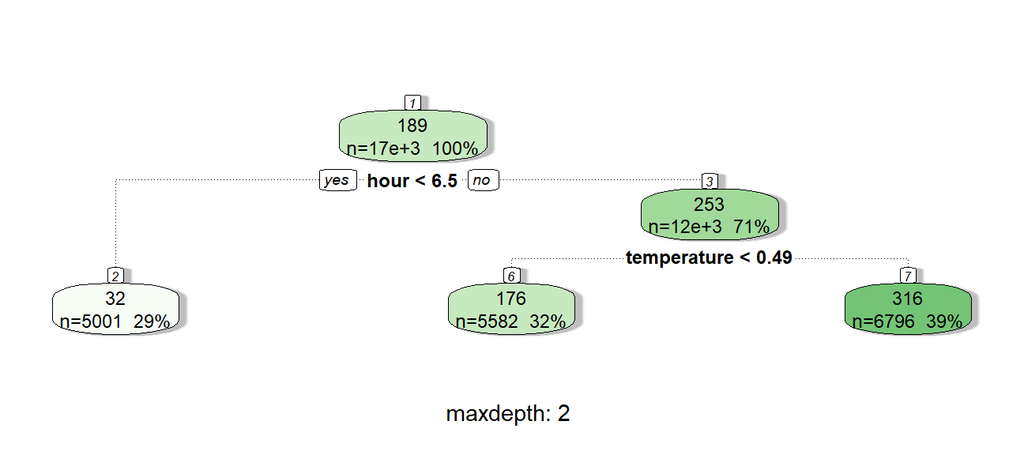

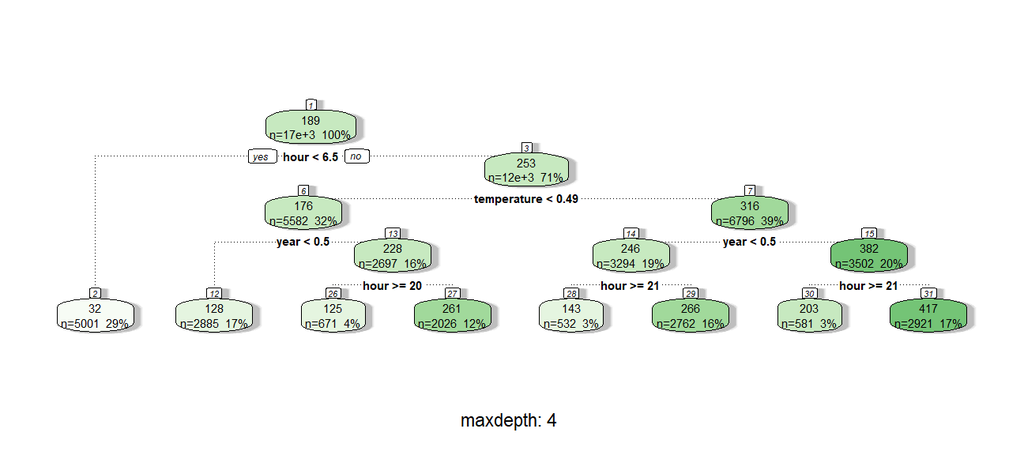

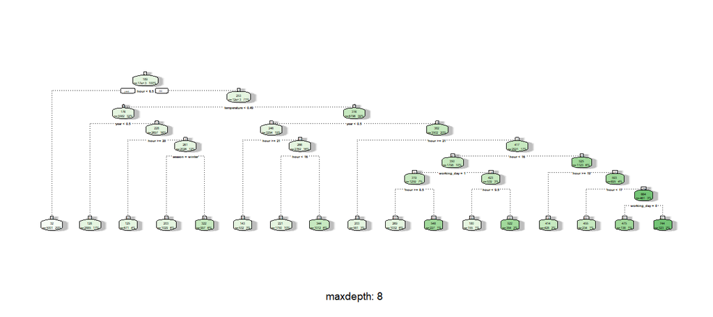

```r
library(mlr3verse)
library(rattle)
task <- tsk("bike_sharing")
task$select(task$feature_names[task$feature_names != "date"])

for (i in c(2, 4, 8)) {
  learner <- lrn("regr.rpart", minsplit = 2, maxdepth = i, minbucket = 1)
  learner$train(task)
  fancyRpartPlot(learner$model, caption = sprintf("maxdepth: %i", i))
}
```

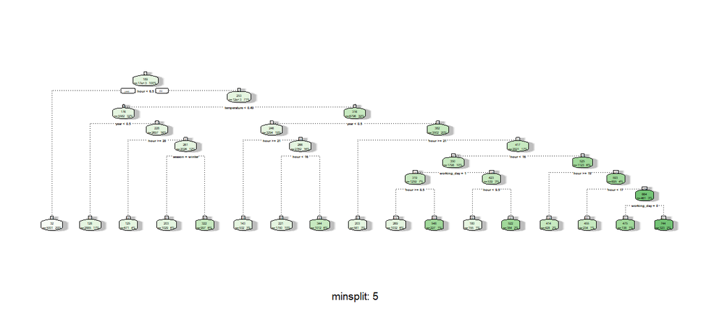

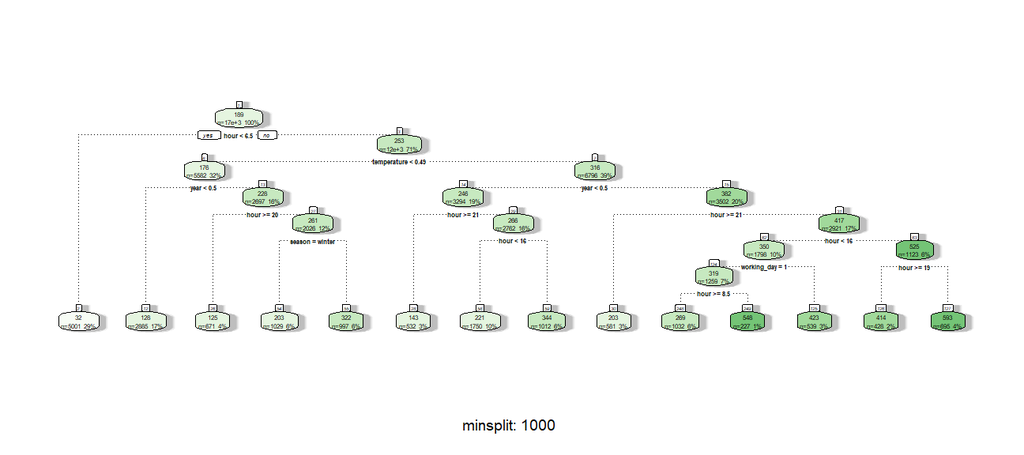

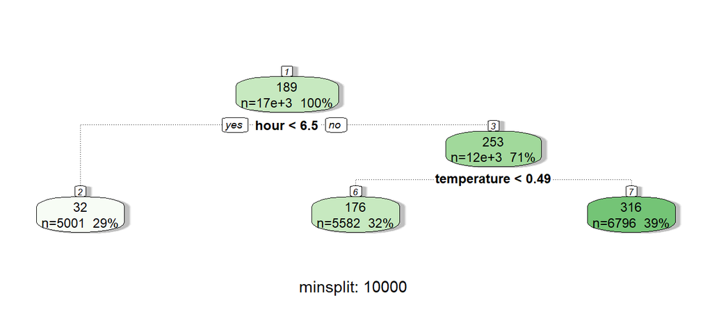

```r
for (i in c(5, 1000, 10000)) {
  learner <- lrn("regr.rpart", minsplit = i, maxdepth = 20, minbucket = 1)
  learner$train(task)
  fancyRpartPlot(learner$model, caption = sprintf("minsplit: %i", i))
}
```

**Python**

Read the data and one-hot encode categorical features (`DecisionTreeRegressor` requires numerical inputs):

```python
bike = pd.read_csv("../data/bike_sharing_for_py.csv")

# drop date, one-hot encode categorical features
bike_x = pd.get_dummies(bike.drop(columns=["count", "date"]))
bike_y = bike["count"]
print(bike_x.shape)
```

```
(17379, 15)
```

Since plots of deep trees become unreadable, we track tree depth and number of leaves instead:

```python
for i in [2, 4, 8]:
    tree = DecisionTreeRegressor(min_samples_split=2, max_depth=i).fit(bike_x, bike_y)
    print("max_depth = %i: tree depth = %i, number of leaves = %i"
          % (i, tree.get_depth(), tree.get_n_leaves()))

for i in [5, 1000, 10000]:
    tree = DecisionTreeRegressor(min_samples_split=i, max_depth=20).fit(bike_x, bike_y)
    print("min_samples_split = %i: tree depth = %i, number of leaves = %i"
          % (i, tree.get_depth(), tree.get_n_leaves()))
```

```
max_depth = 2: tree depth = 2, number of leaves = 4
max_depth = 4: tree depth = 4, number of leaves = 16
max_depth = 8: tree depth = 8, number of leaves = 253
min_samples_split = 5: tree depth = 20, number of leaves = 6424
min_samples_split = 1000: tree depth = 8, number of leaves = 29
min_samples_split = 10000: tree depth = 2, number of leaves = 3
```

For the small trees, a plot analogous to R remains readable:

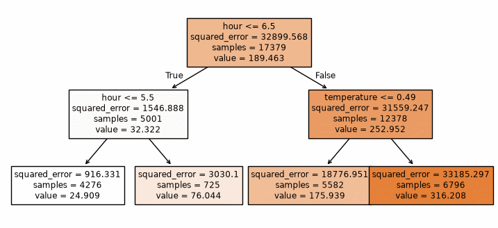

```python
# small trees can also be visualized, similar to R (here: max_depth = 2)
plt.figure(figsize=(9, 4))
tree = DecisionTreeRegressor(min_samples_split=2, max_depth=2).fit(bike_x, bike_y)
plot_tree(tree, feature_names=list(bike_x.columns), filled=True)
plt.show()
```

A higher maximum depth and a lower minimum split size, respectively, produce more complex trees.

3. Which of the two options should we use to control tree appearance?

**Solution**

Both hyperparameters can be used to control tree depth, and their effect depends on the properties of the data-generating process (e.g., at least 100 observations to split further can mean very pure or very impure nodes). Sometimes requirements like interpretability might steer our decision (e.g., a tree of depth 15 is probably hard to interpret). Usually, however, we will employ **hyperparameter tuning** to determine the values for both (and other) hyperparameters, deferring the responsibility from the practitioner to the data.

## Exercise 3: Drawing CART predictions

**TipThe whole exercise is only for lecture group B!**

**NoteLearning goals**

1. Translate between a fitted tree and the corresponding partitioning of the feature space
2. Compute CART predictions by hand

Consider the following classification data with two classes (circles and triangles) and two features $x_1$ and $x_2$:

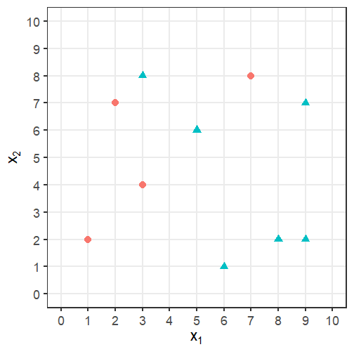

A CART trained on these data performs the following splits:

- first split: $x_1 \leq 4$,
- second split, only for observations with $x_1 > 4$: $x_2 \leq 3$.
1. Draw the partitioning of the feature space induced by the tree into the figure and label the resulting regions $R_1$, $R_2$ and $R_3$.

**Solution**

CART splits are axis-parallel: the first split divides the feature space along the vertical line $x_1 = 4$; the second split only affects the right part, dividing it along the horizontal line $x_2 = 3$ (for $x_1 > 4$):

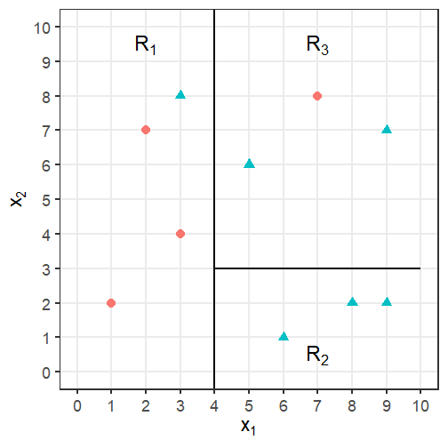

Note how the second split creates a *nested* partition: it subdivides only the region resulting from the first split.

2. State the predicted class for each region.

   **Hint**

   Use the majority of the classes in a region as decision rule.

**Solution**

We count the classes in each region:

- $R_1$ ($x_1 \leq 4$): $3$ circles, $1$ triangle $~\Longrightarrow~$ predict “circle”.
- $R_2$ ($x_1 > 4$, $x_2 \leq 3$): $3$ triangles $~\Longrightarrow~$ predict “triangle”.
- $R_3$ ($x_1 > 4$, $x_2 > 3$): $1$ circle, $2$ triangles $~\Longrightarrow~$ predict “triangle”.
3. Which class does the tree predict for a new observation $(x_1, x_2) = (7, 2)$?

**Solution**

We pass the observation down the tree: $x_1 = 7 > 4$ (go right), $x_2 = 2 \leq 3$ $~\Longrightarrow~$ the observation lands in $R_2$ and is predicted as “triangle”.

4. Finally, sketch the tree corresponding to the given splits. Annotate each leaf node with its predicted class.

**Solution**

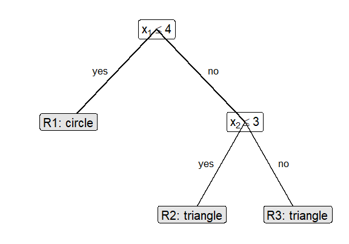

Each inner node corresponds to one split (left branch: condition fulfilled), and each leaf corresponds to one region of the partition from a), labeled with the majority class from b).

## Exercise 4: Impurity reduction

**TipThe whole exercise is only for lecture group A!**

**NoteLearning goals**

1. Derive the optimal constant predictor for regression under L2 loss
2. Develop intuition for use of Brier score in classification trees
3. Reason about distribution and expectations of random variables
4. Handle computations involving expectations

**WarningTLDR;**

This exercise is rather involved and requires some knowledge of probability theory.

Main take-away (besides training proof-type questions): *In constructing CART with minimal Gini impurity, we minimize the expected rate of misclassification across the training data.*

We take a closer look at the theory behind the splitting criteria for both regression and classification trees.

1. Derive the optimal constant predictor for a node $\mathcal{N}$ when minimizing the empirical risk under $L2$ loss and explain why this is equivalent to minimizing variance impurity.

**Solution**

Constant $L2$ risk minimizer for a node $\mathcal{N}$:
$$\bar y = \operatorname{arg\,min}_c \frac{1}{|\mathcal{N}|} \sum_{i = 1}^{|\mathcal{N}|} (y^{(i)}- c)^2,$$

because

$$\begin{align*}
\min_{c \in \mathbb{R}} \frac{1}{|\mathcal{N}|} \sum_{i = 1}^{|\mathcal{N}|} (y^{(i)}- c)^2 &\Longleftrightarrow
\frac{\partial{}}{\partial c} \left( \frac{1}{|\mathcal{N}|} \sum_{i = 1}^{|\mathcal{N}|} (y^{(i)}- c)^2 \right) = 0 \\
&\Longleftrightarrow \frac{1}{|\mathcal{N}|} \frac{\partial{}}{\partial c} \left( \sum_{i = 1}^{|\mathcal{N}|}
\left({y^{(i)}}^2 - 2 y^{(i)}c + c^2\right) \right) = 0 \\
&\Longleftrightarrow \left( \sum_{i = 1}^{|\mathcal{N}|} \left(
-2 y^{(i)}+ 2c\right) \right) = 0 \\
&\Longleftrightarrow |\mathcal{N}| \cdot c = \sum_{i = 1}^{|\mathcal{N}|} y^{(i)}\\
&\Longrightarrow \hat c = \frac{1}{|\mathcal{N}|} \sum_{i = 1}^{|\mathcal{N}|} y^{(i)}
= \bar y.
\end{align*}$$

It’s easy to see that the mean prediction minimizes *variance impurity*.

- We just found that
  $$\bar y = \operatorname{arg\,min}_{c \in \mathbb{R}} \frac{1}{|\mathcal{N}|} \sum_{i = 1}^{|\mathcal{N}|} (y^{(i)}- c)^2.$$
- Looking closely at this minimization objective reveals: it’s simply the (biased) sample variance for sample mean $c$.
- Therefore, predicting the sample mean minimizes both $L2$ risk and variance impurity.

**TipThinking a little further**

- The mean of a sample is precisely the value for which the sum of squared distances to all points is minimal (the “center” of the data).
- Constant mean prediction is equivalent to an intercept LM (trained with $L2$ loss) $\rightsquigarrow$ regression trees with $L2$ loss perform piecewise constant linear regression.

For classification trees, we now build some intuition for the Brier score / Gini impurity as a splitting criterion by showing that it is equal to the expected MCE of the resulting node.

The fractions of the classes $k=1,\ldots, g$ in node $\mathcal{N}$ of a decision tree are $\pi^{(\mathcal{N})}_1,\ldots,\pi^{(\mathcal{N})}_g$, where
$$\pi_k^{(\mathcal{N})}= \frac{1}{|\mathcal{N}|} \sum_{(x^{(i)},y^{(i)}) \in \mathcal{N}} [y^{(i)} = k].$$

For an expression that holds in expectation over arbitrary data, we need to introduce stochasticity. Assume we replace the (deterministic) classification rule in node $\mathcal{N}$
$$\hat{k}~|~\mathcal{N}=\arg\max_k \pi_k^{(\mathcal{N})}$$

by a randomizing rule
$$\hat k \sim \text{Cat} \left(\pi^{(\mathcal{N})}_1,\ldots,\pi^{(\mathcal{N})}_g \right),$$

in which we draw the classes from the categorical distribution of their estimated probabilities (i.e., class $k$ is predicted with probability $\pi^{(\mathcal{N})}_k$).

2. Explain the difference between the deterministic and the randomized classification rule.

**Solution**

The deterministic rule tells us to pick the class with the highest empirical frequency. With the randomizing rule, we draw from a categorical distribution that is parameterized with these same empirical frequencies, meaning we draw the most frequent class with probability $\gamma = \max_k \pi_k^{(\mathcal{N})}$. If we repeat this process many times, we will predict this class $\gamma$ % of the time. Therefore, in expectation, we will also predict the most frequent class in most cases, but the rule is more nuanced as the magnitude of $\gamma$ makes a difference (the closer to 1, the more similar both rules).

3. Using the randomized rule, compute the expected MCE in node $\mathcal{N}$ that contains $n$ random training samples. What do you notice?

**Solution**

In order to compute the expected MCE, we need some random variables (RV) because we want to make a statement that holds for arbitrary training data drawn from the data-generating process. More precisely, we define $n \in \mathbb{N}$ i.i.d. RV $Y^{(1)}, \dots, Y^{(n)}$ that are distributed according to the categorical distribution induced by the observed class frequencies:

$$\mathbb{P}(Y^{(i)} = k| \mathcal{N}) = \pi_k^{(\mathcal{N})}\quad \forall i \in
\{1, \ldots, n\}, \quad k \in \mathcal{Y}.$$

The label $y^{(i)}$ of the $i$-th training observation is thus a realization of the corresponding RV $Y^{(i)}$.

Since our new randomization rule is stochastic, the predictions for the training observations will also be realizations of RV that we denote by $\hat{Y}^{(1)}, ..., \hat{Y}^{(n)}$. By design, they follow the same categorical distribution:

$$\mathbb{P}(\hat Y^{(i)} = k| \mathcal{N}) = \pi_k^{(\mathcal{N})}\quad \forall i \in
\{1, \ldots, n\}, \quad k \in \mathcal{Y}.$$

Then, we can define the MCE for a node with $n = |\mathcal{N}|$ when the randomizing rule is used:

$$\rho_{\text{MCE}}(\mathcal{N}) = \frac{1}{n} \sum\limits_{i=1}^n\left[ Y^{(i)} \neq \hat Y^{(i)}\right].$$

Taking the expectation of this MCE leads to a statement about a node with arbitrary training data:

$$\begin{align*}
\mathbb{E}_{Y^{(1)}, \dots, Y^{(n)}, \hat{Y}^{(1)}, \dots, \hat{Y}^{(n)}}
\left(\rho_{\text{MCE}}(\mathcal{N}) \right)
&= \mathbb{E}_{Y^{(1)}, \dots,Y^{(n)}, \hat{Y}^{(1)}, \dots, \hat{Y}^{(n)}}
\left(\frac{1}{n} \sum\limits_{i=1}^n\left[Y^{(i)} \neq \hat{Y}^{(i)} \right] \right) \\
& = \frac{1}{n} \sum\limits_{i=1}^n\mathbb{E}_{Y^{(i)}, \hat{Y}^{(i)}} \left( \left[Y^{(i)}
\neq \hat{Y}^{(i)} \right]\right) ~~ \text{i.i.d. assumption + linearity} \\
& = \frac{1}{n} \sum\limits_{i=1}^n\mathbb{E}_{Y^{(i)}}\left(
\mathbb{E}_{\hat{Y}^{(i)}} \left( \left[Y^{(i)} \neq \hat{Y}^{(i)} \right] \right)
\right) ~~ \text{Fubini's theorem} \\
& = \frac{1}{n} \sum\limits_{i=1}^n\mathbb{E}_{Y^{(i)}} \left( \sum_{k \in \mathcal{Y}} \pi_k^{(\mathcal{N})}\cdot
\left[ Y^{(i)} \neq k \right] \right) \\
% & = \meanin \E_{Y^{(i)}} \left( \sum_{k \in \Yspace
% \setminus \{Y^{(i)}\}} \pikN \right) \\
& = \frac{1}{n} \sum\limits_{i=1}^n\mathbb{E}_{Y^{(i)}} \left( 1 - \pi^{(\mathcal{N})}_{k = Y^{(i)}}
\right) \\
& = \frac{1}{n} \sum\limits_{i=1}^n\sum\limits_{k=1}^g\pi_k^{(\mathcal{N})}\cdot \left(1 - \pi_k^{(\mathcal{N})}\right) \\
& = n \cdot \frac{1}{n} \sum\limits_{k=1}^g\pi_k^{(\mathcal{N})}\cdot \left(1 - \pi_k^{(\mathcal{N})}\right) \\
&= \sum\limits_{k=1}^g\pi_k^{(\mathcal{N})}\cdot \left(1 - \pi_k^{(\mathcal{N})}\right).
\end{align*}$$

This is precisely the Gini index CART use for splitting with Brier score. Gini impurity can thus be viewed as the expected frequency with which the training samples will be misclassified in a given node $\mathcal{N}$.

In other words, in constructing CART with minimal Gini impurity, we minimize the expected rate of misclassification across the training data.